# Report

Jules Brable

2023-02-07

### DATA IMPORTATION

```r
library(tidyverse)

source(here::here("R/functions/statdesc_functions.R"))
source(here::here("R/functions/sampling_functions.R"))

df <- load_data("data.csv")

pma <- c("Infertility Treatment Used",
         "Fertility Enhancing Drugs",
         "Asst. Reproductive Technology")
```

```r
#df2021 <- load_data("nat2021us.csv")

#df2021 %>%
  #filter(rf_inftr == "Y") %>%
  #nrow()

#df2021 %>%
  #filter(rf_fedrg == "Y") %>%
  #nrow()

#df2021 %>%
  #filter(rf_artec == "Y") %>%
  #nrow()

#df2021 %>%
  #filter(rf_inftr == "Y", rf_fedrg == "N", rf_artec == "N") %>%
  #nrow()

#rm(df2021)
```

```r
## wrangling data

# removing "na"
df <- df %>%
  filter(meduc != 9, fagerec11 != 11, frace6 != 9, feduc != 9, apgar5 != 5, priorlive != 99)

# recoding mrace15 into mrace6 (properly)
df <- df %>%
  mutate(
    mrace6 = case_when(
      between(mrace15, 4, 10) ~ 4,
      between(mrace15, 11, 14) ~ 5,
      mrace15 == 15 ~ 6,
      TRUE ~ as.numeric(mrace15)
      ),
    Group = case_when(
      rf_inftr == "N" ~ "NT",
      TRUE ~ "T")
    )

df %>% dim()
```

```
## [1] 1014642     240
```

# STAT DESC

Sur les 1014642 données de notre échantillon (2018 + 2019 + 2020 + 2021), on a:

| Response | Infertility Treatment Used | Fertility Enhancing Drugs | Asst. Reproductive Technology |
| --- | --- | --- | --- |
| N | 47.055 | 29.703 | 16.597 |
| Y | 52.945 | 20.612 | 33.718 |
| U | 0.000 | 2.630 | 2.630 |
| X | 0.000 | 47.055 | 47.055 |

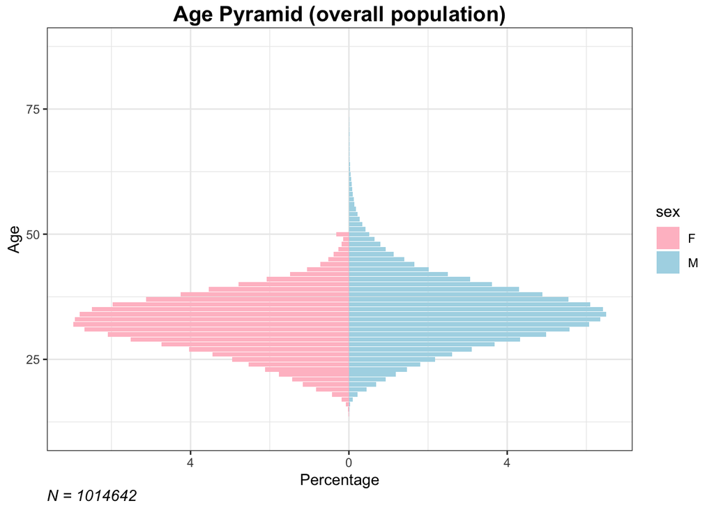

```r
df %>%
  transform_age() %>%
  pyrage(title="Age Pyramid (overall population)")
```

### Population cible

```r
pop <- df %>% filter(rf_fedrg == "Y")
pop %>% dim()
```

```
## [1] 209138    240
```

```r
popnc <- df %>% filter(rf_fedrg != "Y")
popnc %>% dim()
```

```
## [1] 805504    240
```

Parmi ceux qui ont eu recours à des traitements contre l’infertilité, voici la répartition du recours ou non à des traitements contre l’infertilité sous forme de médicaments ou insémination artificielle ou sous forme d’assisted reproductive technology (ART) (IVF ou autres): :

```r
df %>%
  filter(rf_inftr == "Y") %>%
  get_prop(rf_fedrg) %>%
  full_join(df %>%
              filter(rf_inftr == "Y") %>%
              get_prop(rf_artec),
            by = c("rf_fedrg" = "rf_artec")) %>%
  replace(is.na(.), 0) %>%
  rename_all(function(x) c("Response", pma[-1])) %>%
  kableExtra::kbl() %>%
  template()
```

| Response | Fertility Enhancing Drugs | Asst. Reproductive Technology |
| --- | --- | --- |
| N | 56.102 | 31.347 |
| U | 4.967 | 4.967 |
| Y | 38.931 | 63.685 |

**Répartition de la population cible selon le nombre d’enfants avant cette naissance:**

```r
pop %>% get_prop(priorlive) %>%
  kableExtra::kbl() %>%
  template()
```

| priorlive | Frequency |
| --- | --- |
| 0 | 57.515 |
| 1 | 30.284 |
| 2 | 8.355 |
| 3 | 2.601 |
| 4 | 0.813 |
| 5 | 0.272 |
| 6 | 0.087 |
| 7 | 0.040 |
| 8 | 0.008 |
| 9 | 0.005 |
| 10 | 0.011 |
| 11 | 0.004 |
| 12 | 0.005 |

```r
popnc %>%
  get_prop(priorlive) %>%
  kableExtra::kbl() %>%
  template()
```

| priorlive | Frequency |
| --- | --- |
| 0 | 45.274 |
| 1 | 32.387 |
| 2 | 13.576 |
| 3 | 5.264 |
| 4 | 1.996 |
| 5 | 0.794 |
| 6 | 0.349 |
| 7 | 0.170 |
| 8 | 0.083 |
| 9 | 0.048 |
| 10 | 0.032 |
| 11 | 0.014 |
| 12 | 0.009 |
| 13 | 0.003 |
| 14 | 0.001 |
| 15 | 0.000 |
| 16 | 0.000 |
| 20 | 0.000 |

### Age des parents

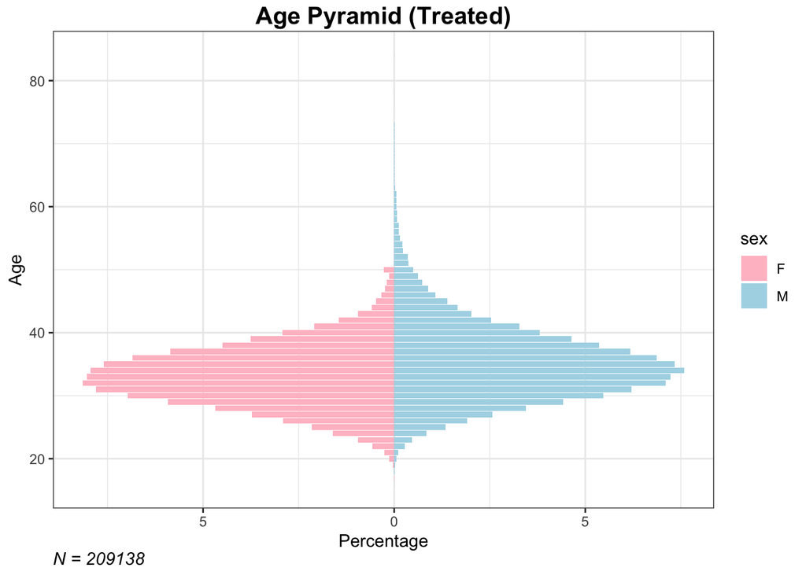

```r
pop %>%
  transform_age() %>%
  pyrage(title="Age Pyramid (Treated)")
```

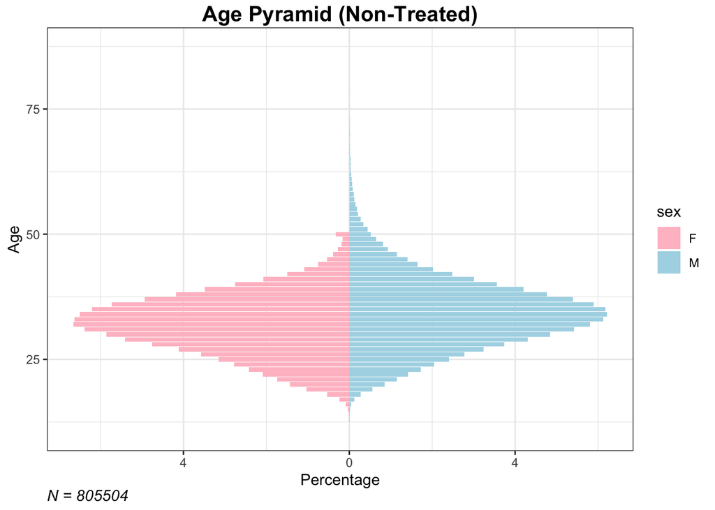

```r
popnc %>%
  transform_age() %>%
  pyrage(title="Age Pyramid (Non-Treated)")
```

```r
fage <- data.frame(Age = c("< 15", "15-19", "20-24", "25-29", "30-34", "35-39", "40-44", "45-49", "50-54", "55-98"), code = as.factor(c(1:10)))

fage %>%
  mutate(`Father's age (years)` = Age, .keep = "unused") %>%
  left_join(y = pop %>%
              get_prop(fagerec11) %>%
              data.frame(),
            by = c("code" = "fagerec11")
  ) %>%
  mutate(`Treated` =   replace_na(Frequency, 0), .keep = "unused") %>%
  left_join(y = popnc %>%
              get_prop(fagerec11) %>%
              data.frame() %>%
              rename(`Non-Treated` = Frequency),
            by = c("code" = "fagerec11")) %>%
  kableExtra::kbl() %>%
  template()
```

| code | Father’s age (years) | Treated | Non-Treated |
| --- | --- | --- | --- |
| 1 | < 15 | 0.000 | 0.004 |
| 2 | 15-19 | 0.026 | 1.013 |
| 3 | 20-24 | 1.743 | 7.197 |
| 4 | 25-29 | 13.692 | 16.473 |
| 5 | 30-34 | 33.591 | 28.411 |
| 6 | 35-39 | 30.400 | 26.446 |
| 7 | 40-44 | 13.308 | 12.720 |
| 8 | 45-49 | 4.711 | 4.944 |
| 9 | 50-54 | 1.656 | 1.786 |
| 10 | 55-98 | 0.874 | 1.007 |

```r
mage <- data.frame(Age = c("< 15", "15-19", "20-24", "25-29", "30-34", "35-39", "40-44", "45-49", "50-54"), code = as.factor(c(1:9)))

mage %>%
  mutate(`Mother's age (years)` = Age, .keep = "unused") %>%
  left_join(y = pop %>%
              get_prop(mager9) %>%
              data.frame(),
            by = c("code" = "mager9")
  ) %>%
  mutate(`Treated` =   replace_na(Frequency, 0), .keep = "unused") %>%
  left_join(y = popnc %>%
              get_prop(mager9) %>%
              data.frame() %>%
              rename(`Non-Treated` = Frequency),
            by = c("code" = "mager9")) %>%
  kableExtra::kbl() %>%
  template()
```

| code | Mother’s age (years) | Treated | Non-Treated |
| --- | --- | --- | --- |
| 1 | < 15 | 0.000 | 0.007 |
| 2 | 15-19 | 0.051 | 1.920 |
| 3 | 20-24 | 3.505 | 10.452 |
| 4 | 25-29 | 19.368 | 21.016 |
| 5 | 30-34 | 38.888 | 32.025 |
| 6 | 35-39 | 28.557 | 24.541 |
| 7 | 40-44 | 7.993 | 8.169 |
| 8 | 45-49 | 1.370 | 1.546 |
| 9 | 50-54 | 0.267 | 0.324 |

```r
pop %>%
  transform_age() %>%
  summary("age")
```

```
##       age           sex
##  Min.   :16.0   Length:418276
##  1st Qu.:30.0   Class :character
##  Median :34.0   Mode  :character
##  Mean   :34.2
##  3rd Qu.:37.0
##  Max.   :84.0
```

```r
popnc %>%
  transform_age() %>%
  summary("age")
```

```
##       age            sex
##  Min.   :11.00   Length:1611008
##  1st Qu.:29.00   Class :character
##  Median :33.00   Mode  :character
##  Mean   :33.11
##  3rd Qu.:37.00
##  Max.   :87.00
```

Sur la population cible, l’âge médian des hommes est de 35 ans, contre 33 ans pour les femmes.

Sur les non traités, l’âge médian des hommes est de 34 ans, contre 32 ans pour les femmes.

### Ethnie des parents

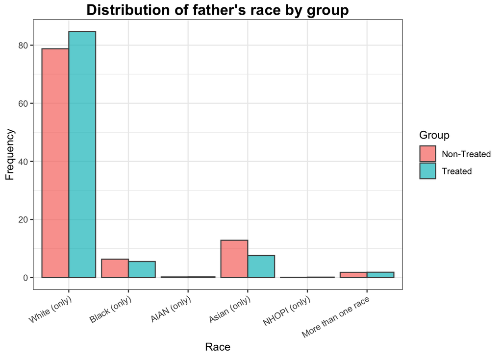

```r
recode_labels <- c(
  "1" = "White (only)",
  "2" = "Black (only)",
  "3" = "AIAN (only)",
  "4" = "Asian (only)",
  "5" = "NHOPI (only)",
  "6" = "More than one race"
  )
quick_title <- "father's race"

df %>%
  mutate(frace6 = recode(
    factor(frace6),
    !!!recode_labels
    )) %>%
  plot_discrete_group(
    var=frace6,
    quick_title=quick_title,
    x="Race"
    ) +
  scale_x_discrete(guide = guide_axis(angle = 30))
```

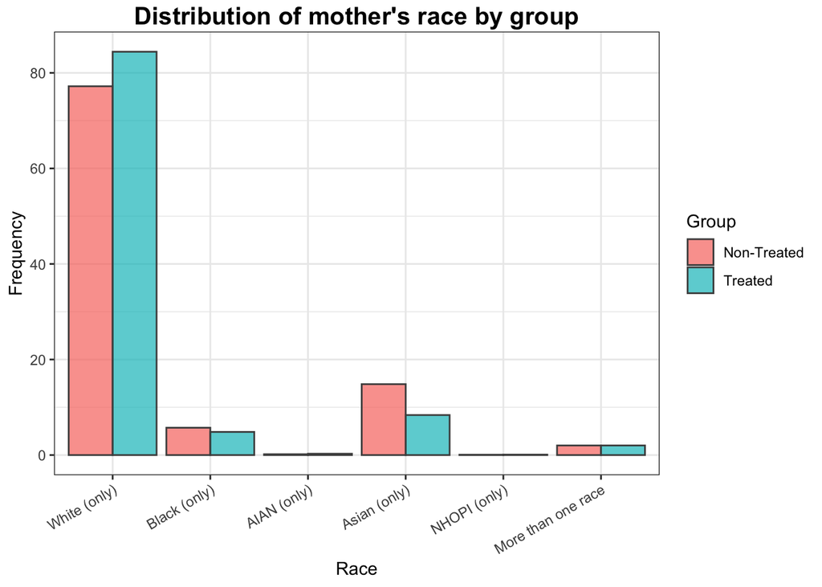

```r
quick_title <- "mother's race"

df %>%
    mutate(mrace6 = recode(factor(mrace6), !!!recode_labels)) %>%
  plot_discrete_group(
    var=mrace6,
    quick_title=quick_title,
    x="Race"
    ) +
  scale_x_discrete(guide = guide_axis(angle = 30))
```

### Education des parents

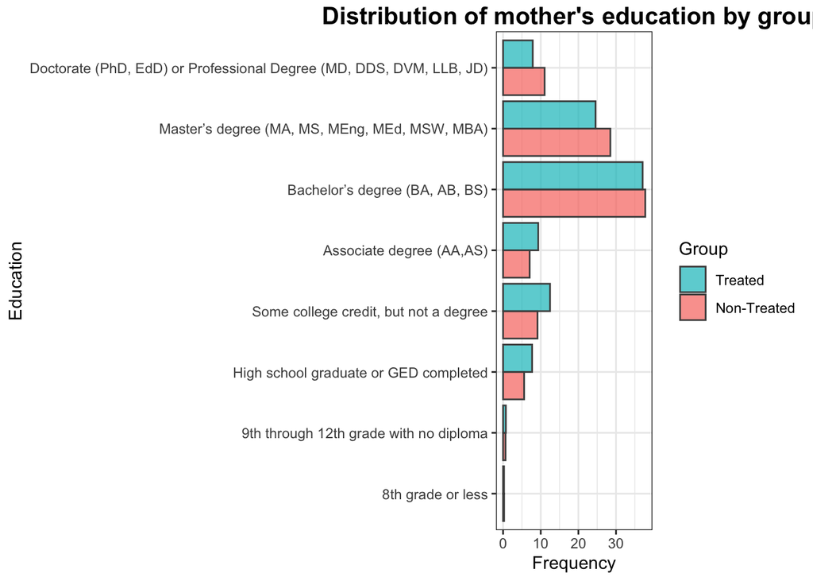

```r
recode_labels <- c(
  "1"="8th grade or less",
  "2"="9th through 12th grade with no diploma",
  "3"="High school graduate or GED completed",
  "4"="Some college credit, but not a degree",
  "5"="Associate degree (AA,AS)",
  "6"="Bachelor’s degree (BA, AB, BS)",
  "7"="Master’s degree (MA, MS, MEng, MEd, MSW, MBA)",
  "8"="Doctorate (PhD, EdD) or Professional Degree (MD, DDS, DVM, LLB, JD)"
  )
quick_title <- "mother's education"

df %>%
  mutate(meduc = recode(factor(meduc), !!!recode_labels)) %>%
  plot_discrete_group(
    var=meduc,
    quick_title=quick_title,
    x="Education"
    ) +
  guides(fill = guide_legend(reverse=TRUE)) +
  coord_flip()
```

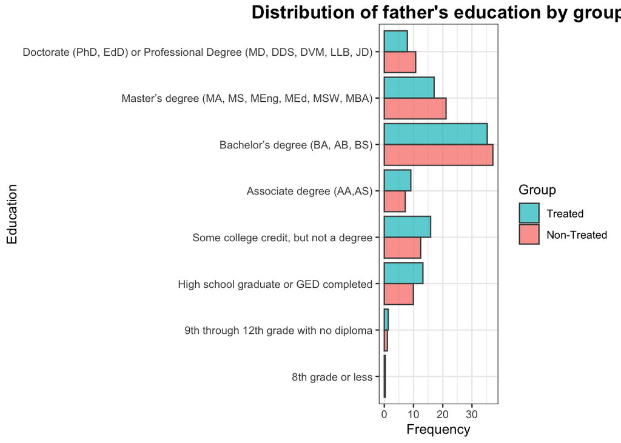

```r
quick_title <- "father's education"

df %>%
  mutate(feduc = recode(factor(feduc), !!!recode_labels)) %>%
  plot_discrete_group(
    var=feduc,
    quick_title=quick_title,
    x="Education"
    ) +
  guides(fill = guide_legend(reverse=TRUE)) +
  coord_flip()
```

### Caractéristiques du couple

```r
df %>%
  mutate(`Marital status` = recode(dmar, "1"="Married", "2"="Unmarried")) %>%
  group_freq(`Marital status`, "Marital status")
```

| Group | Marital status | freq |
| --- | --- | --- |
| NT | Married | 60.482 |
| NT | Unmarried | 27.649 |
| NT | NA | 11.869 |
| T | Married | 86.745 |
| T | Unmarried | 3.923 |
| T | NA | 9.331 |

```r
df %>%
  mutate(priorlive = case_when(
    as.numeric(priorlive) >= 4 ~ "4+",
    TRUE ~ as.character(priorlive)
    )) %>%
  group_freq(priorlive, "Prior live")
```

| Group | Prior live | freq |
| --- | --- | --- |
| NT | 0 | 38.349 |
| NT | 1 | 33.168 |
| NT | 2 | 16.925 |
| NT | 3 | 6.904 |
| NT | 4+ | 4.655 |
| T | 0 | 56.194 |
| T | 1 | 30.874 |
| T | 2 | 8.567 |
| T | 3 | 2.770 |
| T | 4+ | 1.594 |

QUESTION : doit-on recoder ainsi la variable “priorlive”? Sinon, va jusqu’à 20 mais avec des effectifs très faibles.

```r
df %>% grouped_summary(priorlive, "prior live")
```

*Statistical summary of prior live:*

| Group | min | max | mean | sd | IQR |
| --- | --- | --- | --- | --- | --- |
| NT | 0 | 20 | 1.11 | 1.27 | 2 |
| T | 0 | 14 | 0.64 | 0.93 | 1 |

```r
df %>% group_freq(dplural, "Twinning")
```

| Group | Twinning | freq |
| --- | --- | --- |
| NT | 1 | 97.068 |
| NT | 2 | 2.872 |
| NT | 3 | 0.057 |
| NT | 4 | 0.003 |
| T | 1 | 81.216 |
| T | 2 | 17.467 |
| T | 3 | 1.217 |
| T | 4 | 0.092 |
| T | 5 | 0.009 |

```r
df %>% grouped_summary(dplural, "twinning")
```

*Statistical summary of twinning:*

| Group | min | max | mean | sd | IQR |
| --- | --- | --- | --- | --- | --- |
| NT | 1 | 4 | 1.03 | 0.17 | 0 |
| T | 1 | 5 | 1.20 | 0.44 | 0 |

### Santé de l’enfant

```r
df %>% group_freq(apgar5r, "Score Apgar 5")
```

| Group | Score Apgar 5 | freq |
| --- | --- | --- |
| NT | 1 | 0.496 |
| NT | 2 | 1.017 |
| NT | 3 | 12.916 |
| NT | 4 | 85.239 |
| NT | 5 | 0.332 |
| T | 1 | 0.906 |
| T | 2 | 1.575 |
| T | 3 | 16.127 |
| T | 4 | 81.195 |
| T | 5 | 0.197 |

```r
df %>% filter(apgar5 != 99) %>% grouped_summary(apgar5, "Score Apgar 5")
```

*Statistical summary of Score Apgar 5:*

| Group | min | max | mean | sd | IQR |
| --- | --- | --- | --- | --- | --- |
| NT | 0 | 10 | 8.8 | 0.75 | 0 |
| T | 0 | 10 | 8.7 | 0.93 | 0 |

```r
df %>% filter(dbwt != 9999) %>% grouped_summary(dbwt, "birth weight")
```

*Statistical summary of birth weight:*

| Group | min | max | mean | sd | IQR |
| --- | --- | --- | --- | --- | --- |
| NT | 227 | 8165 | 3284.83 | 572.23 | 655 |
| T | 227 | 6700 | 3104.77 | 710.70 | 831 |

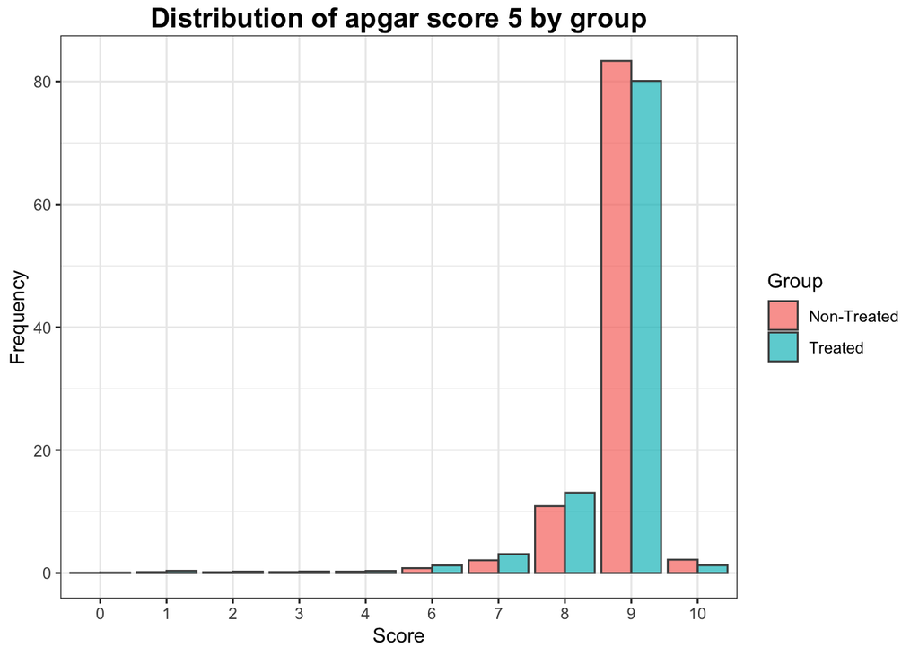

```r
df %>%
  filter(rf_inftr == "Y" | rf_inftr == "N", apgar5 != 99) %>%

  # summarizing the variable to get the percentage by group

  group_by(rf_inftr, apgar5) %>%
  summarise(n = n()) %>%
  mutate(freq = n * 100 / sum(n)) %>%

  # plot the 2 distributions (treated and NT) of the variable
  ggplot(mapping = aes(x = as.factor(apgar5), y = freq, fill = factor(rf_inftr))) +
  geom_bar(color = "grey30",
           alpha = 0.7,
           position = "dodge",
           stat = "identity") +
  scale_fill_discrete(name = "Group", labels = c("Non-Treated", "Treated")) +
  labs(title = glue::glue("Distribution of apgar score 5 by group"), x = "Score", y = "Frequency") +
  theme_formatted()
```

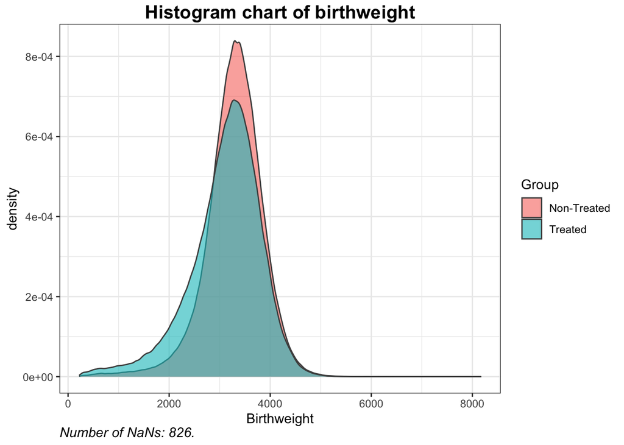

```r
title <- glue::glue("Histogram chart of birthweight")

caption <- df %>% create_caption(var = "dbwt", nan = 9999)

df %>%
  dplyr::filter(dbwt != 9999) %>%
  ggplot2::ggplot(mapping = aes(x = dbwt, fill = rf_inftr)) +
  ggplot2::geom_density(color = "grey30", alpha = 0.6) +
  ggplot2::labs(title = title, x = "Birthweight", caption = caption) +
  scale_fill_discrete(name = "Group", labels = c("Non-Treated", "Treated")) +
  theme_formatted()
```

## Régressions linéaires

```r
to_keep <- c("dbwt", "mager", "meduc", "mrace6", "fagerec11", "feduc", "frace6", "priorlive", "dmar", "rf_artec")
df_reg <- df %>% select(to_keep)
```

Régression du poids à la naissance sur plusieurs variables explicatives (dont l’age de la mere au carré):

```r
df_reg$age2 <- df_reg$mager**2
df_reg$ldbwt <- df_reg$dbwt %>% log()

res <- lm(ldbwt ~ .,
       data = df_reg)
```

```r
stargazer::stargazer(res, type = "html")
```

|  | *Dependent variable:* |
| --- | --- |
|  | ldbwt |
| dbwt | 0.0004*** |
|  | (0.00000) |
| mager | -0.002*** |
|  | (0.0001) |
| meduc | 0.001*** |
|  | (0.0001) |
| mrace6 | 0.001*** |
|  | (0.0001) |
| fagerec11 | 0.0001 |
|  | (0.0001) |
| feduc | 0.001*** |
|  | (0.0001) |
| frace6 | 0.0005*** |
|  | (0.0001) |
| priorlive | -0.0004*** |
|  | (0.0001) |
| dmar | 0.002*** |
|  | (0.0003) |
| rf_artecU | 0.001 |
|  | (0.001) |
| rf_artecX | 0.007*** |
|  | (0.0003) |
| rf_artecY | -0.002*** |
|  | (0.0003) |
| age2 | 0.00003*** |
|  | (0.00000) |
| Constant | 6.872*** |
|  | (0.002) |
| Observations | 907,845 |
| R<sup>2</sup> | 0.886 |
| Adjusted R<sup>2</sup> | 0.886 |
| Residual Std. Error | 0.092 (df = 907831) |
| F Statistic | 545,257.400*** (df = 13; 907831) |
| *Note:* | p<0.1; p<0.05; p<0.01 |

En ajoutant l’année :

```r
df_reg <- df %>% select(to_keep, dob_yy)
df_reg$age2 <- df_reg$mager**2

res <- lm(dbwt ~ .,
       data = df_reg)
```

```r
stargazer::stargazer(res, type = "html")
```

|  | *Dependent variable:* |
| --- | --- |
|  | dbwt |
| mager | 25.042*** |
|  | (1.072) |
| meduc | 11.978*** |
|  | (0.615) |
| mrace6 | -29.712*** |
|  | (0.782) |
| fagerec11 | -2.157*** |
|  | (0.764) |
| feduc | 15.149*** |
|  | (0.559) |
| frace6 | -29.344*** |
|  | (0.809) |
| priorlive | 1.333* |
|  | (0.696) |
| dmar | -52.678*** |
|  | (2.240) |
| rf_artecU | 57.852*** |
|  | (4.484) |
| rf_artecX | 246.641*** |
|  | (2.150) |
| rf_artecY | 27.155*** |
|  | (2.147) |
| dob_yy | 7.006*** |
|  | (0.636) |
| age2 | -0.380*** |
|  | (0.016) |
| Constant | -11,460.260*** |
|  | (1,284.091) |
| Observations | 907,845 |
| R<sup>2</sup> | 0.029 |
| Adjusted R<sup>2</sup> | 0.029 |
| Residual Std. Error | 677.626 (df = 907831) |
| F Statistic | 2,092.709*** (df = 13; 907831) |
| *Note:* | p<0.1; p<0.05; p<0.01 |

En ajoutant la gémélité:

```r
df_reg <- df %>% select(to_keep, dplural)
MR3 <- lm(dbwt ~ .,
          data = df_reg)
```

```r
stargazer::stargazer(MR3, type = "html")
```

|  | *Dependent variable:* |
| --- | --- |
|  | dbwt |
| mager | -3.855*** |
|  | (0.183) |
| meduc | 16.945*** |
|  | (0.548) |
| mrace6 | -30.720*** |
|  | (0.705) |
| fagerec11 | 1.145* |
|  | (0.688) |
| feduc | 13.100*** |
|  | (0.504) |
| frace6 | -27.245*** |
|  | (0.730) |
| priorlive | 42.240*** |
|  | (0.629) |
| dmar | -74.102*** |
|  | (1.975) |
| rf_artecU | 11.838*** |
|  | (4.042) |
| rf_artecX | 58.023*** |
|  | (1.978) |
| rf_artecY | 17.019*** |
|  | (1.929) |
| dplural | -867.202*** |
|  | (1.892) |
| Constant | 4,230.710*** |
|  | (6.189) |
| Observations | 907,845 |
| R<sup>2</sup> | 0.211 |
| Adjusted R<sup>2</sup> | 0.211 |
| Residual Std. Error | 610.890 (df = 907832) |
| F Statistic | 20,221.420*** (df = 12; 907832) |
| *Note:* | p<0.1; p<0.05; p<0.01 |

```r
df_reg <- df %>% select(to_keep, dplural, dob_yy)

MR4 <- lm(dbwt ~ .,
          data = df_reg)
```

```r
stargazer::stargazer(MR4, type = "html")
```

|  | *Dependent variable:* |
| --- | --- |
|  | dbwt |
| mager | -3.835*** |
|  | (0.183) |
| meduc | 17.014*** |
|  | (0.548) |
| mrace6 | -30.725*** |
|  | (0.705) |
| fagerec11 | 1.097 |
|  | (0.688) |
| feduc | 13.080*** |
|  | (0.504) |
| frace6 | -27.239*** |
|  | (0.730) |
| priorlive | 42.274*** |
|  | (0.629) |
| dmar | -73.897*** |
|  | (1.975) |
| rf_artecU | 10.974*** |
|  | (4.043) |
| rf_artecX | 58.226*** |
|  | (1.978) |
| rf_artecY | 17.467*** |
|  | (1.929) |
| dplural | -868.053*** |
|  | (1.894) |
| dob_yy | -5.385*** |
|  | (0.574) |
| Constant | 15,106.400*** |
|  | (1,159.024) |
| Observations | 907,845 |
| R<sup>2</sup> | 0.211 |
| Adjusted R<sup>2</sup> | 0.211 |
| Residual Std. Error | 610.861 (df = 907831) |
| F Statistic | 18,674.490*** (df = 13; 907831) |
| *Note:* | p<0.1; p<0.05; p<0.01 |

### Corélation entre le recours à médicaments et la gémélité

```r
gemelite <- lm(dplural ~ mager + rf_fedrg + rf_artec, data=df)
```

```r
stargazer::stargazer(gemelite, type = "html")
```

|  | *Dependent variable:* |
| --- | --- |
|  | dplural |
| mager | -0.001*** |
|  | (0.0001) |
| rf_fedrgU | -0.055*** |
|  | (0.003) |
| rf_fedrgX | -0.194*** |
|  | (0.002) |
| rf_fedrgY | -0.005*** |
|  | (0.002) |
| rf_artecU |  |
| rf_artecX |  |
| rf_artecY | -0.017*** |
|  | (0.002) |
| Constant | 1.264*** |
|  | (0.003) |
| Observations | 1,014,642 |
| R<sup>2</sup> | 0.061 |
| Adjusted R<sup>2</sup> | 0.061 |
| Residual Std. Error | 0.340 (df = 1014636) |
| F Statistic | 13,133.060*** (df = 5; 1014636) |
| *Note:* | p<0.1; p<0.05; p<0.01 |

Reste à faire des tests d’indépendance (Khi2/KS/Student)